#### **C:\Users\ANKIT DIMRI.vscode\Complete Programming\Python program\Python tutedude\DJANGO**

# **Project -**

- **1. test_1**
- **2. hellowrold**
- **3. Temp**
- **4. DTL**
- **5. login**
- **6. login_1**
- **7. web**
- **8. config**
- **9. website**

# **DJANGO -[FrameWork]**

- Django makes it easier to build better web apps more quickly and with less code.
  - Ridiculously fast
  - Reassuringly Secure
  - Exceedingly scalable
- [Web Development ---> Frame Work]
  - Frame Work --> Set of codes that are already predefined
    - Web frame Work --> Web Development
      - Installing process ..
        - tzdata, sqlparse, asgiref, django

  djangoproject.com
- - 1.Creating project
  - 2.Creating an app
  - 3.3.Creating files using DJANGO
  - 4.User registration(part)
  - 4.Django Template Language
  - 5.Adding Numbers :-
  - GET vs POST
  - MVT
  - Static Files
  - Static Files
  - User-Registeration And Login redirect
  - LOGOUT FORMAT
  - fORMS WEB/WEBapp
  - CREATING YOUR OWN BLOG
  - **pip install Django**

  > https://sqlitebrowser.org/dl/ for dbsqlite

# 1. **createproject**

- **django-admin startproject [blog]- project_name**
- **then create the app**
  - **python manage.py startapp [app_name]**
- **then migrate the data**
  - **[python manage.py makemigrations/migrate]**
    - **ctrl+c to terminate the program**
- [

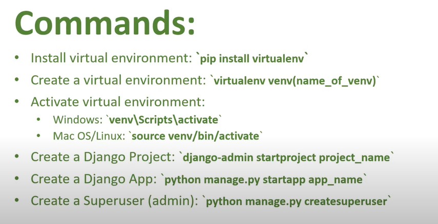

  ]

### 1.Creating project

- - django-admin --version to check the version
  - django-admin ro check the subcommands :
    - check, compilemessages, createcachetable, dbshell, diffsettings, dumpdata, flush, inspectdb, loaddata, makemessages, makemigrations, migrate, optimizemigration, runserver, sendtestemail, shell, showmigrations, sqlflush, sqlmigrate, sqlsequencereset, squashmigrations, startapp, startproject, test, testserver,
    - django-admin startproject test_1
    - goto the file cd with file name
    - and type - python file_name runserver - shows the result like this
- You have 18 unapplied migration(s). Your project may not work properly until you apply the migrations for app(s): admin, auth, contenttypes, sessions.
- Run 'python manage.py migrate' to apply them.
- January 04, 2023 - 18:50:19
- Django version 4.1.5, using settings 'test_1.settings'
- Starting development server at http://127.0.0.1:8000/
- Quit the server with CTRL-BREAK.

## then copy the 8000 and type in new tab with localhost:8000 or whatever the number

[figure not shown]

- **Quit the server with CTRL-BREAK. If you want to break the server then press ctrl + c**

### 2.Creating an app

- - **python manage.py migrate to check the migrate files** then
  - **python manage.py startapp testapp [to create the app in the DJANGO file folder]**
  - C:\Users\ANKIT DIMRI.vscode\Complete Programming\Python program\Python tutedude\DJANGO\test_1>python manage.py runserver
- - - - Watching for file changes with StatReloader
      - Performing system checks...
      - System check identified no issues (0 silenced).
      - January 05, 2023 - 12:47:18
      - Django version 4.1.5, using settings 'test_1.settings'
      - Starting development server at http://127.0.0.1:8000/
      - Quit the server with CTRL-BREAK.
    - Then we can see there is no issue which all are shows in upper cases
- - for creating the user name and other details
    - C:\Users\ANKIT DIMRI.vscode\Complete Programming\Python program\Python tutedude\DJANGO\test_1>python - - **manage.py createsuperuser**
    - Username (leave blank to use 'ankitdimri'): testuser
    - Email address:
    - Password:
    - Password (again):
    - This password is too short. It must contain at least 8 characters.
    - This password is too common.
    - Bypass password validation and create user anyway? [y/N]: n
    - Password:
    - Password (again):
    - Superuser created successfully.
    - C:\Users\ANKIT DIMRI.vscode\Complete Programming\Python program\Python tutedude\DJANGO\test_1>
      - password - micro1234#
    - jango-admin startproject helloworld
    - python manage.py startapp helloapp

# 3.Creating files using DJANGO Helloworld

- first goto views.py and wrtie the same line program
  - views.py
    - **from django.shortcuts import render**
- [

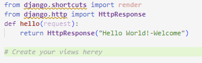

  ]
- **then goto the settngs in INSTALLED_APPS AND type in the 'filename' or function name**
  - [

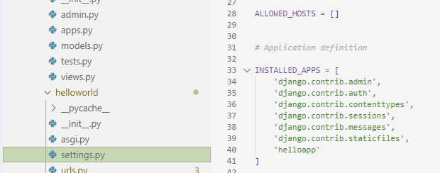

    ]
- then goto the **urls.py**
  - [

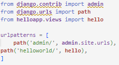

    ]
- **django-admin startproject login**
- **python manage.py startapp accounts**
  - [

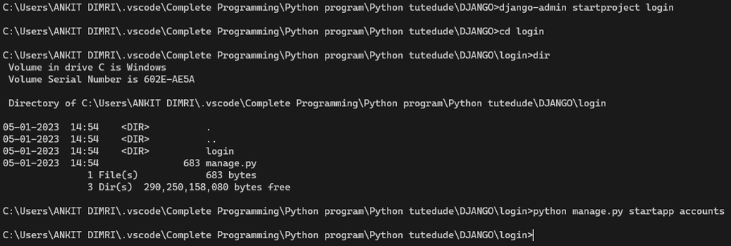

    ]
- create the directory inside the accounts one folder templates
- create one other folder registration one file inside the folder register.html and one file in the templates index.html
- **index.html**

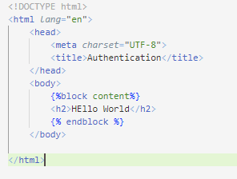

- **register.html**

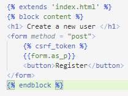

- then copy the urls files from login to accounts and write the details
- **login urls** - [

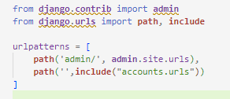

  ]
- **accounts urls** - [

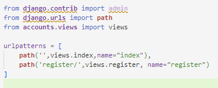

  ]
- **Username: djangogo12**
- **Password: asdf12#@#**
- http://127.0.0.1:8000/admin/login/?next=/admin/
  - goto the login info
- 1. **first create the .html file**
  - [

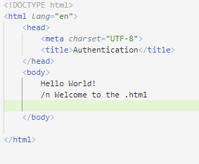

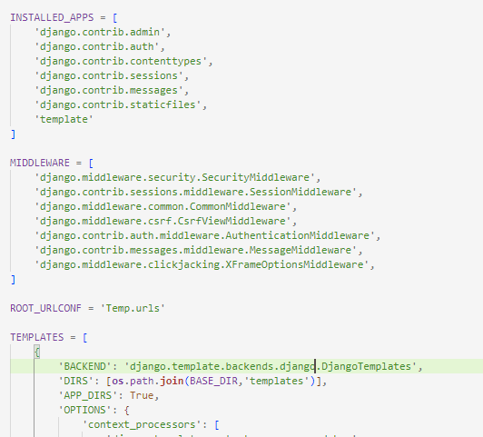

     ]
- 4. **goto ulrs.py**
  - [

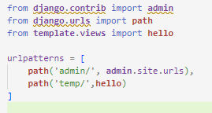

    ]

# **4.Django Template Language -:**

- **django-admin startproject DTL**
- **python manage.py startapp Design**
- **python manage.py migrate**
- **python mangae.py runserver**
  - first we type the templete file in the html format
    - [

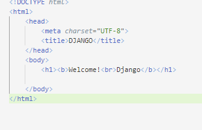

      ]
  - goto the views file
    - [

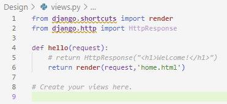

      ]
  - goto the settings file
    - [

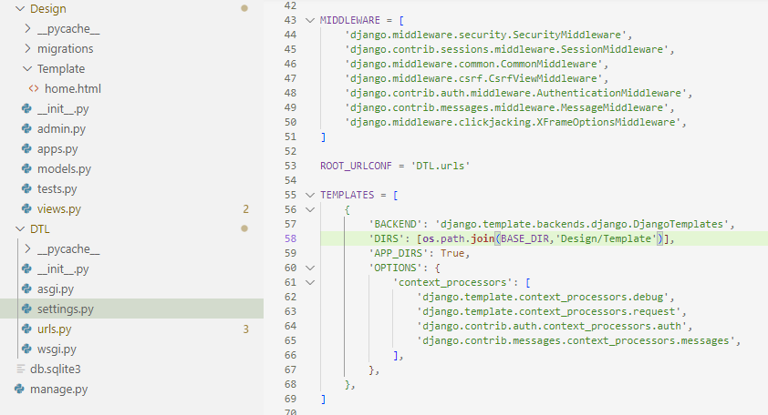

      ]
    - [

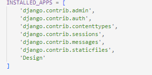

      ]
  - goto the urls file
    - [

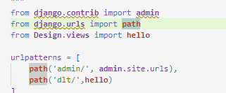

      ]
  - how look like the directory
    - [

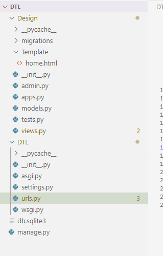

      ]

# **5.Adding Numbers :-**

- - [

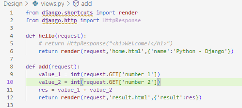

    ]
- - [

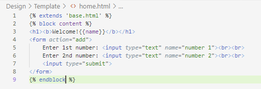

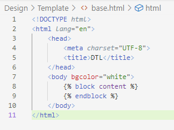

    ]
- - [

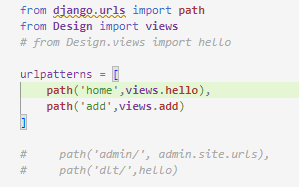

    ]

# **GET vs POST**

- CSRF verification failed. Request aborted.
  - Cross Site Request Forgery, or when Django’s CSRF mechanism
- if u want to fit some data through the internet just go with the GET
- but if u want to data just use the post
- [

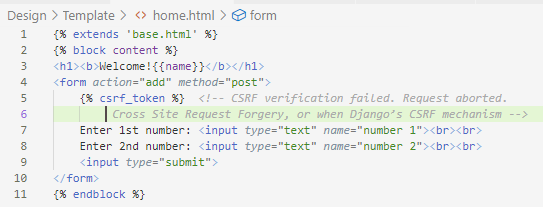

  ]
- [

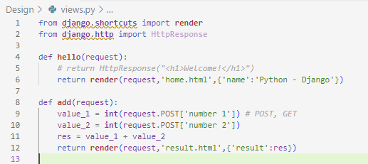

  ]
- [

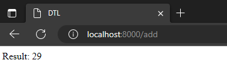

  ] Without any complicated Urls

# **MVT**

- [

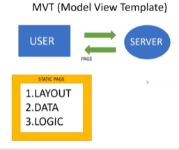

  ]
- [

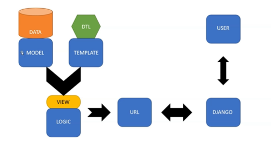

  ]